# Polynomial Class

Ryan Hastings, Mishek Thapa

May 27th, 2020

Assignment for STA 323: Statistical Programming

In this assignment, we create a class of polynomials using the `S3` object-oriented programming environment in `R`. A polynomial is constructed from two numeric vectors, one of coefficients and another of their respective powers.

### Class Description

We created a class of polynomials. A polynomial is constructed from a numeric vector of coefficients and uses its two attributes: the class, polynomial and powers, a numeric vector of each coefficient’s respective power. The helper function here converts inputs of strings into numerical vectors for the user and helps uncover some invalid inputs by creating NAs.

These two components of the constructor were supplemented with the validity checks in the validator function. The inputs that were filtered for: vectors with NA values, infinite values, and inputs that are not numbers. This step is significant because it gets rid of any non-real number inputs that could have been entered (characters, symbols, imaginary numbers). Another validity check was the check to make sure each vector (coefficient and power) were the same length.

### Functions

Our constructor function:

```r
new_polynomial <- function(x = double(), y = double()) {

  # assign attributes to coefficient vector x
  structure(x,
            powers = y,
            class = "polynomial")
}
```

Our validator function:

```r
validate_polynomial <- function(x) {

  values <- unclass(x) #get the underlying base classes
  pow <-  attr(values,"powers")

  if (any(is.na(values)) | any(is.nan(values)) | any(is.infinite(values))) {
    stop("Coefficients are either infinite, not a number, or not available",call. = FALSE)
  }

  if (any(is.na(pow)) | any(is.nan(pow)) | any(is.infinite(pow))) {
    stop("Powers are either infinite, not a number, or not available", call. = FALSE)
  }

  if(length(x) != length(attr(x,"powers"))) {
    stop("The quantity of coefficients must be the same as the quantity of powers",call. = FALSE)
  }

  return(x)
}
```

Our helper function:

```r
polynomial <- function(x, y = 0:(length(x)-1)){

  # coerce inputs to type numeric
  x <- suppressWarnings(as.numeric(x))
  y <- suppressWarnings(as.numeric(y))

  # input into validator and constructor
  validate_polynomial(new_polynomial(x, y))

}
```

### Methods

The combination of these two components of the class allow for building upon a few generic functions, specifically the print and the plot function. These two functions cycled through the two vectors to produce their output. First, the print function cycles through the elements of each vector in order and writes one element of the expression and uses the paste function to combine the compo- nents of the equations. The plot function creates a domain of x values to compute into the polynomial (can be defined by user), then cycles through each element of the polynomial (like the print function) and adds them to compute each value in the function, then plots all the points.

Our `print` method:

```r
print.polynomial <- function(x, ...) {

  # create a string displaying coefficients and their powers
  str <- paste(as.character(x),
               " * x ^ ",
               as.character(attr(x, "powers")),
               sep = "",
               collapse = " + ")

  str <- paste("f(x) = ", str)
  print(str, ...)
}
```

Our `plot` method:

```r
plot.polynomial <- function(poly,
                            lower = -5, # lower bound of region displayed
                            upper =  5, # upper bound of region displayed
                            step  = .1, # distance between each point evaluated
                            main  = "Polynomial Plot",
                            ylab  = "f(x)",
                            sub = print(poly),
                            type = "l",
                            ...) {

  #validation; stopifnot produces interpretable messages here
  stopifnot(attr(poly, "class") == "polynomial",
            is.numeric(lower),
            is.numeric(upper),
            is.numeric(step),
            !is.infinite(lower),
            !is.infinite(upper),
            !is.nan(lower),
            !is.nan(upper))

  # create function to evaluate a polynomial at a point
  eval_poly <- function(poly, num) {

    value <- 0

    for (i in 1:length(poly)) {
      value <- value + poly[i] * (num ^ (attr(poly, "powers")[i]))
    }

    return(value)
    }
  # generate function inputs and outputs to be plotted
  x <- seq(lower, upper, step)
  y <- eval_poly(poly, x)

  # plot using specified settings
  plot(x, y, main = main, ylab = ylab, sub = sub, type = type, ...)
}
```

### Usability and Robustness

By building on these generic functions with this class, the user can also use optional features for each of these functions like different types of plotting styles for example. This makes the function very robust and easy to use. A downside of this function is that the function takes in coefficients and powers separately. This is not a very typical way of representing a polynomial, but it permits an efficient way to process the inputs. After understanding the input format though, the methods this class allows for are useful and very easy to use.

Examples:

```r
m <- polynomial(1, 2)
attributes(m)
```

```
$powers
[1] 2

$class
[1] "polynomial"
```

```r
print(m)
```

```
[1] "f(x) =  1 * x ^ 2"
```

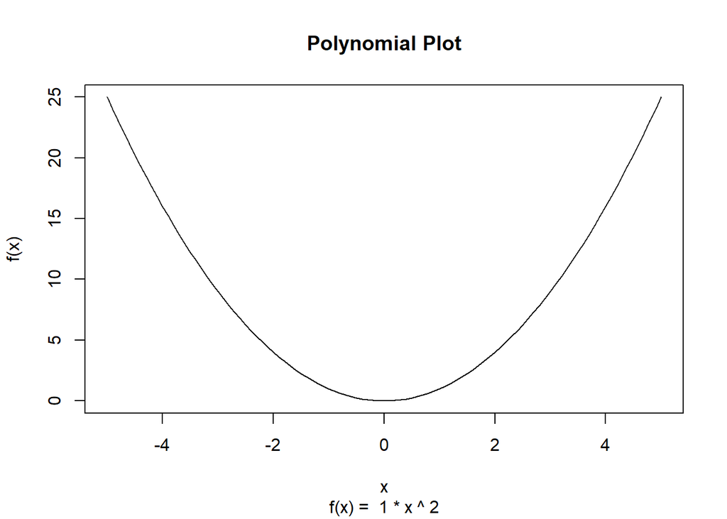

```
[1] "f(x) =  1 * x ^ 2"
```

```r
plot(m)
```

```r
j <- polynomial(1:5, 5:9)
print(j)
```

```
[1] "f(x) =  1 * x ^ 5 + 2 * x ^ 6 + 3 * x ^ 7 + 4 * x ^ 8 + 5 * x ^ 9"
```

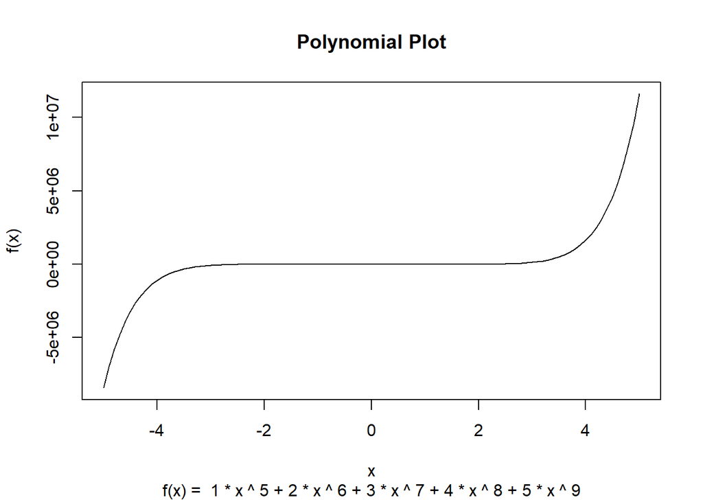

```
[1] "f(x) =  1 * x ^ 5 + 2 * x ^ 6 + 3 * x ^ 7 + 4 * x ^ 8 + 5 * x ^ 9"
```

```r
plot(j)
```

```r
n <- polynomial(pi)
print(n)
```

```
[1] "f(x) =  3.14159265358979 * x ^ 0"
```

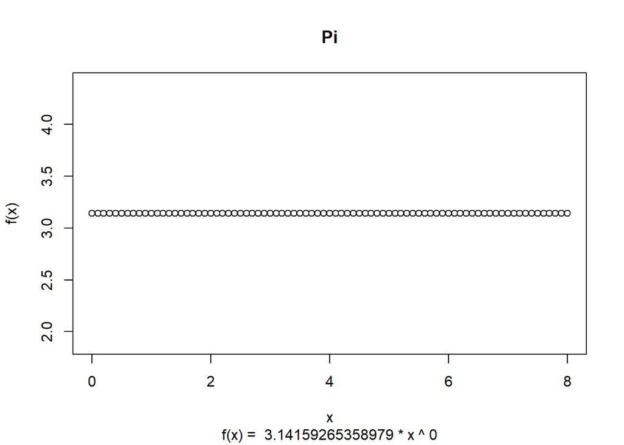

```
[1] "f(x) =  3.14159265358979 * x ^ 0"
```

```r
plot(n, lower = 0, upper = 8, main = "Pi", type = "p")
```

```r
k <- polynomial(c(1, 3, 4, 2), c(-2:0, 1.4))
print(k)
```

```
[1] "f(x) =  1 * x ^ -2 + 3 * x ^ -1 + 4 * x ^ 0 + 2 * x ^ 1.4"
```

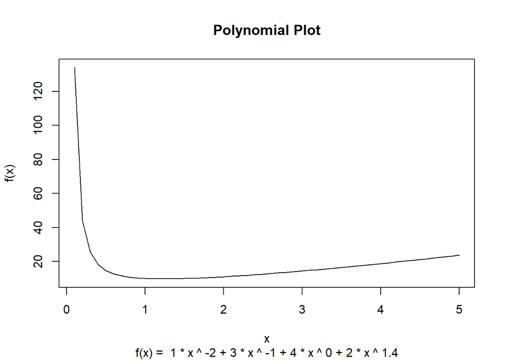

```
[1] "f(x) =  1 * x ^ -2 + 3 * x ^ -1 + 4 * x ^ 0 + 2 * x ^ 1.4"
```

```r
plot(k, lower = 0.1, step = 0.1)
```

```r
a <- polynomial(0.5, -1)
print(a)
```

```
[1] "f(x) =  0.5 * x ^ -1"
```

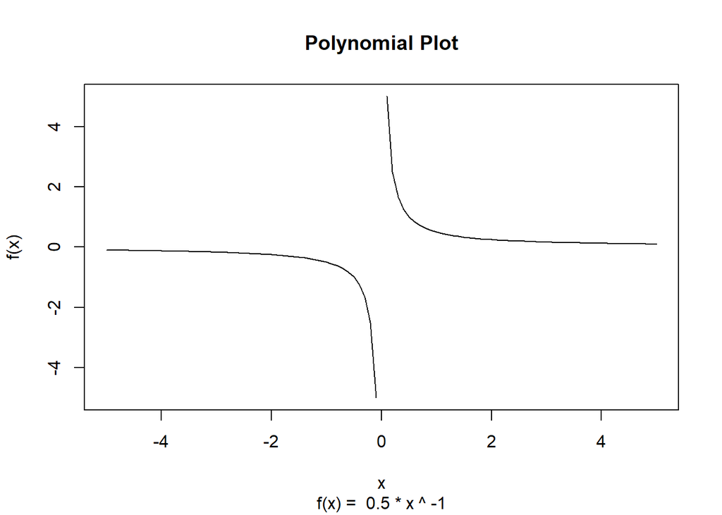

```
[1] "f(x) =  0.5 * x ^ -1"
```

```r
plot(a, step = 0.1)
```